# Annex for Data Science Capstone Project Report

## Most Frequently-Used Phrases

### Constructing word-frequency lookup table

Instead of merely looking at frequently-used single words, I want to find the most frequently-used phrases (in particular 3- and 4-word phrases).

### Build Corpus, Tokenization and Clean Text Data

The following steps are taken to prepare the word-frequency lookup table from the samples:

- convert all characters to lower case
- remove the punctuation
- remove the numbers
- remove the white space
- skip stemming and removal of sparse terms, in order to consider all words used in reviews

```r
corpus <- Corpus(VectorSource(df_review_samples$text))
corpus <- tm_map(corpus, content_transformer(tolower))
corpus <- tm_map(corpus, removePunctuation)
corpus <- tm_map(corpus, removeNumbers)
corpus <- tm_map(corpus, stripWhitespace)

# Tokenizing the corpus and construct N-Grams
# Will only construct 3-gram, and 4-gram tokenizers as 1-gram and 2-gram does not seem to show much insight into the question of interest
# Tokenizer for n-grams and passed on to the term-document matrix constructor
TdmTri <- TermDocumentMatrix(corpus, control = list(tokenize = TrigramTokenizer))
TdmQuad <- TermDocumentMatrix(corpus, control = list(tokenize = QuadgramTokenizer))
# Remove NAs
TdmTri <- slam::rollup(TdmTri, 2, na.rm=TRUE, FUN = sum)
TdmQuad <- slam::rollup(TdmQuad, 2, na.rm=TRUE, FUN = sum)
# Term frequency
freq.tri <- rowSums(as.matrix(TdmTri))
freq.quad <- rowSums(as.matrix(TdmQuad))
##sort
freq.tri <- sort(freq.tri, decreasing = TRUE)
freq.quad <- sort(freq.quad, decreasing = TRUE)
# Create the top X data frames from the matrices
topnum <- 30
df.freq.tri <- data.frame("Term"=names(head(freq.tri,topnum)), "Frequency"=head(freq.tri,topnum))
df.freq.quad <- data.frame("Term"=names(head(freq.quad,topnum)), "Frequency"=head(freq.quad,topnum))
# Reorder levels for better plotting
df.freq.tri$Term1 <- reorder(df.freq.tri$Term, df.freq.tri$Frequency)
df.freq.quad$Term1 <- reorder(df.freq.quad$Term, df.freq.quad$Frequency)
# clear memory
rm(TdmTri)
rm(TdmQuad)
```

### Bar plots for N-Grams Token

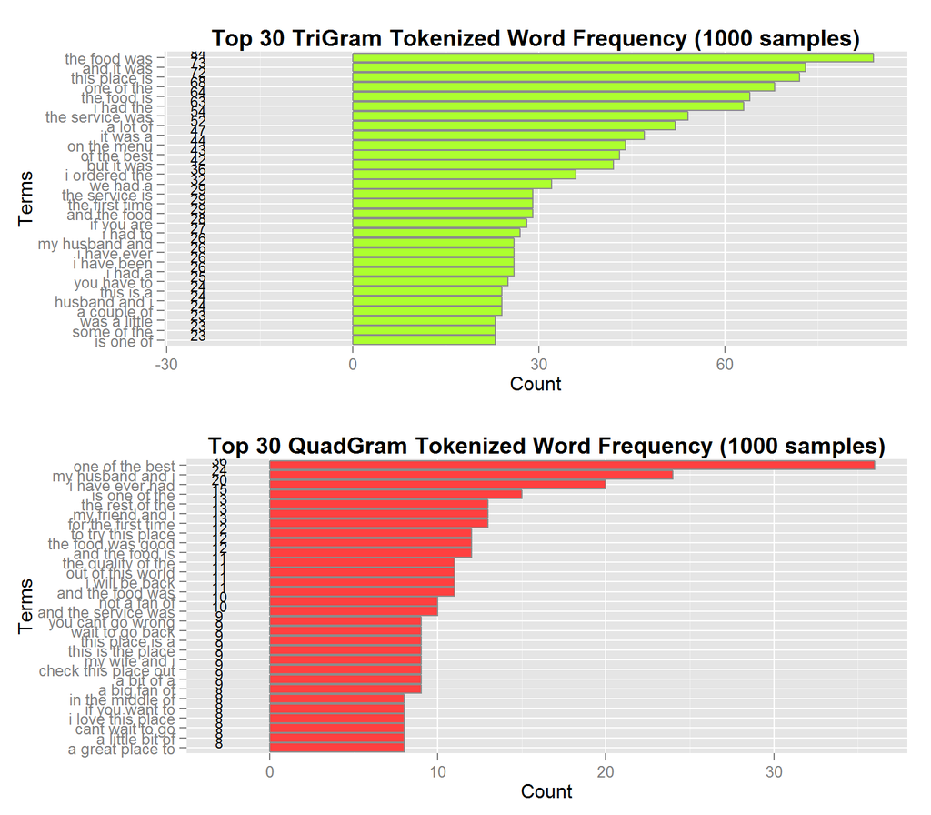

```r
p3 <-
    ggplot(df.freq.tri, aes(x = Term1, y = Frequency)) +
    geom_bar(stat = "identity", color="gray55", fill="greenyellow") +
    geom_text(data=df.freq.tri,aes(x=Term1,y=-25,label=Frequency),vjust=0, size=3) +
    xlab("Terms") + ylab("Count") + ggtitle("Top 30 TriGram Tokenized Word Frequency (1000 samples)") +
    theme(plot.title = element_text(lineheight=.8, face="bold")) +
    coord_flip()

p4 <-
    ggplot(df.freq.quad, aes(x = Term1, y = Frequency)) +
    geom_bar(stat = "identity", color="gray55", fill="brown1") +
    geom_text(data=df.freq.quad,aes(x=Term1,y=-3,label=Frequency),vjust=0, size=3) +
    xlab("Terms") + ylab("Count") + ggtitle("Top 30 QuadGram Tokenized Word Frequency (1000 samples)") +
    theme(plot.title = element_text(lineheight=.8, face="bold")) +
    coord_flip()
multiplot(p3, p4, cols=1)
```

### Word Clouds for the N-Gram Tokens

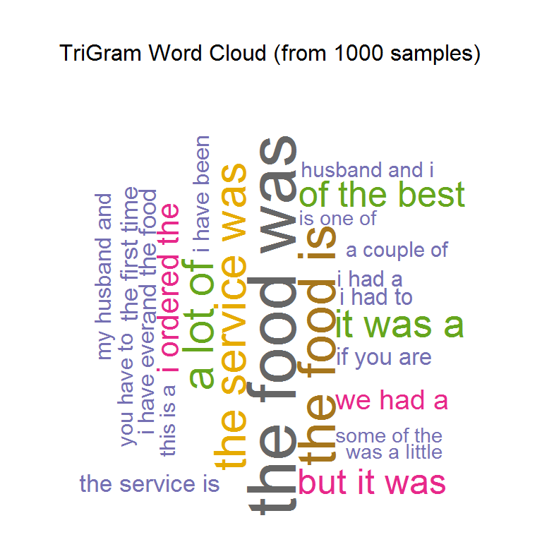

```r
renderWordCloud (words = df.freq.tri$Term1,
                 freq = df.freq.tri$Frequency,
                 max.words = 30,
                 title = "TriGram Word Cloud (from 1000 samples)",
                 scale = c(3,0.1))
```

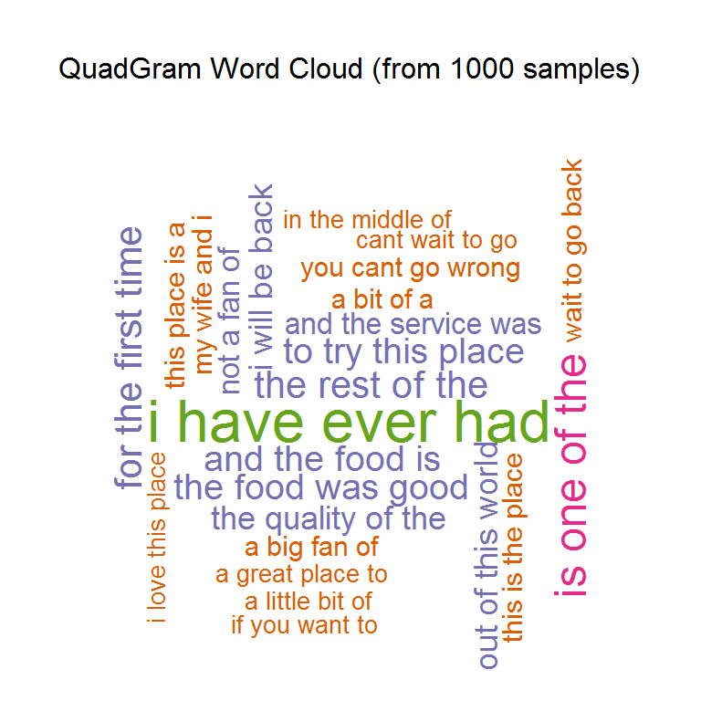

```r
renderWordCloud (words = df.freq.quad$Term1,
                 freq = df.freq.quad$Frequency,
                 max.words = 30,
                 title = "QuadGram Word Cloud (from 1000 samples)",
                 scale = c(3.5,0.1))
```

It is observed that the most-frequently used phrases are:

- Tri-grams: “the food was”, “and it was”, “this place is”, “the food is”, “i had the”, “the service was”, “the service is” etc
- Quad-grams: “one of the best”, “my husband and I”, “i have ever had”, “is one of the”, “the rest of the”, “my friend and i”, “for the first time” etc

The tri-grams top results further supports the inference that “food” and “place” (which may refer to service or physical environment) are what drives customers to write reviews. It is observed that the 4-word phrases is more complete while 3-word phrases tend to be truncated and incomplete. It is easier to infer the key important ideas for customers from 4-word phrases. With this, I decided to focus on only Quad-grams.

# Results

Now I apply the same steps on the full dataset of 883750 reviews.

```r
df_review_samples <- df_rest_reviews

# extract reviews of different rating
df_reviews_01star <- df_review_samples[df_review_samples$stars==1,]
df_reviews_02star <- df_review_samples[df_review_samples$stars==2,]
df_reviews_03star <- df_review_samples[df_review_samples$stars==3,]
df_reviews_04star <- df_review_samples[df_review_samples$stars==4,]
df_reviews_05star <- df_review_samples[df_review_samples$stars==5,]
```

From a sample of 883750 reviews, there are 75625 1-star, 85181 2-star, 135323 3-star, 285231 4-star and 302390 5-star reviews.

## Results for 1-star Reviews

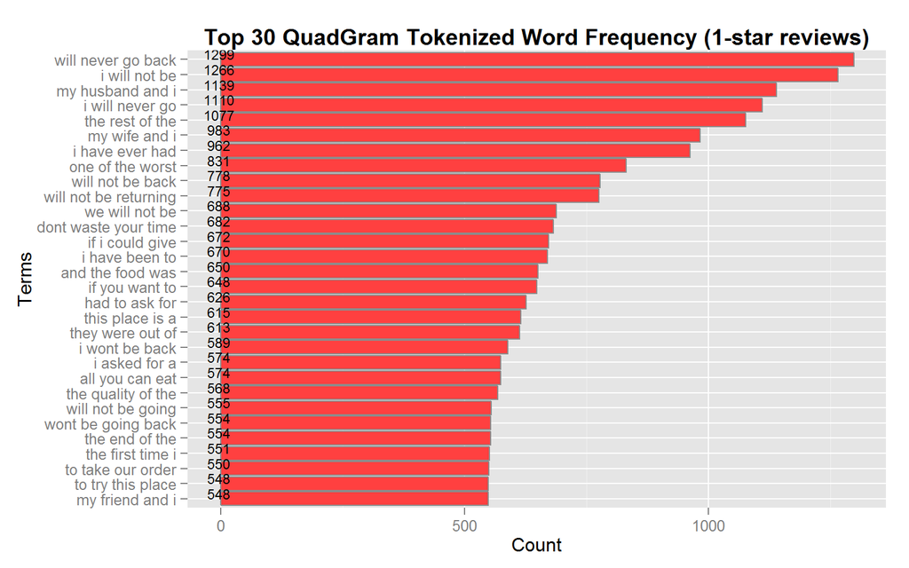

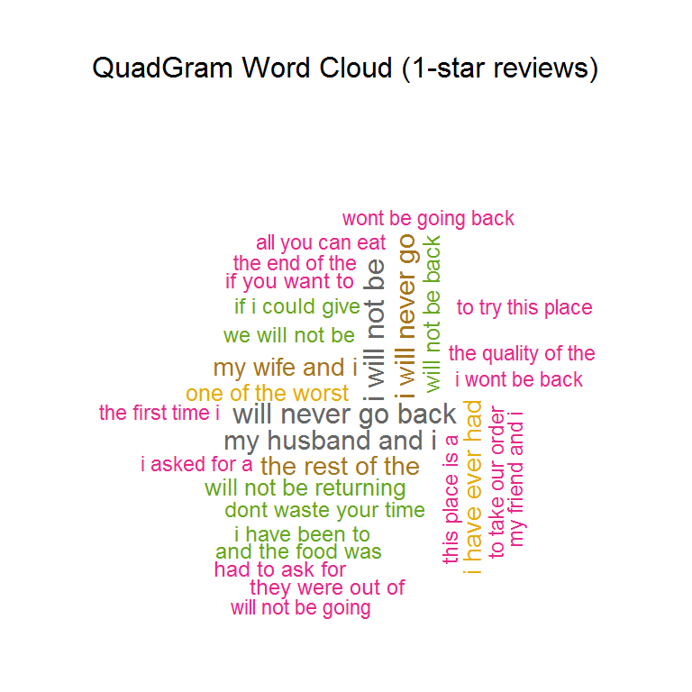

## Results for 2-star Reviews

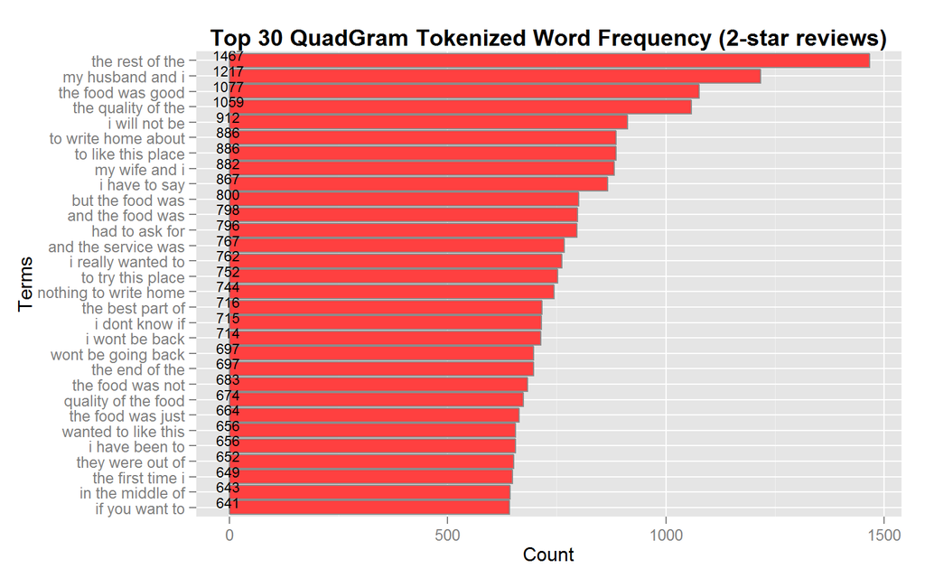

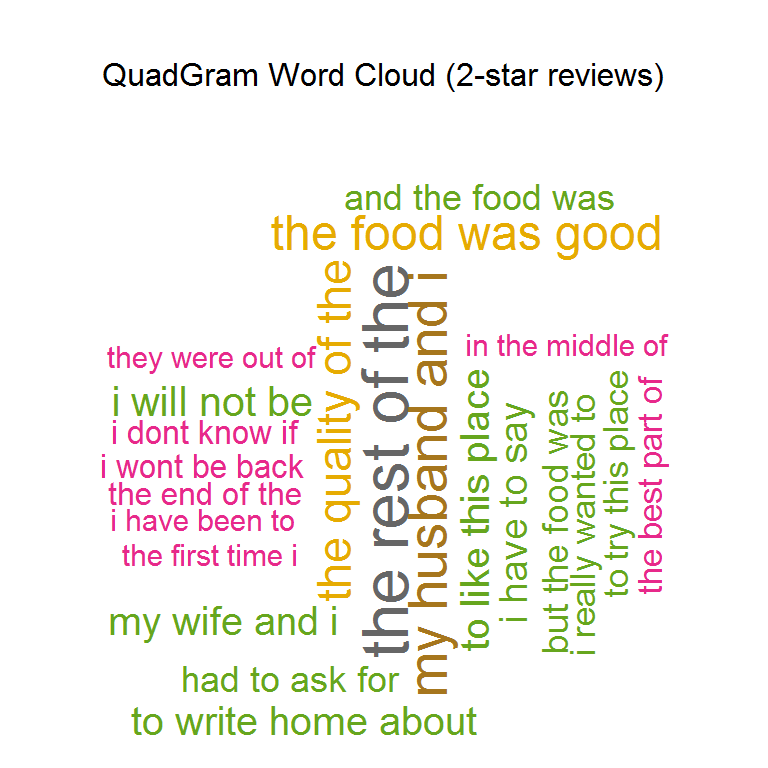

## Results for 3-star Reviews

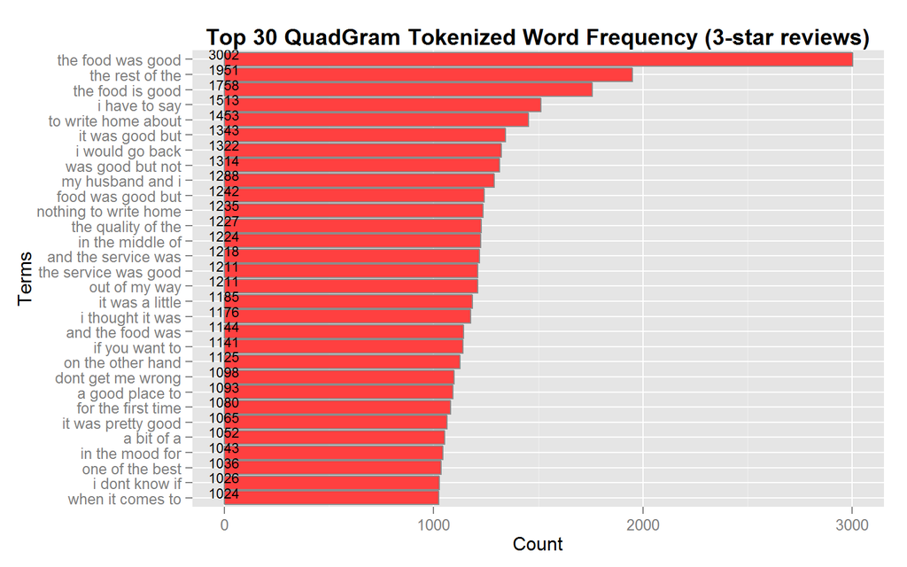

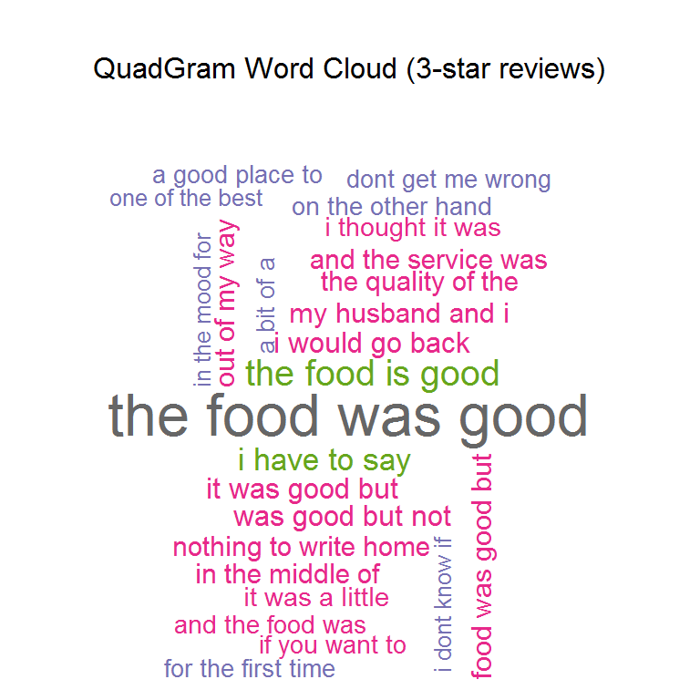

## Results for 4-star Reviews

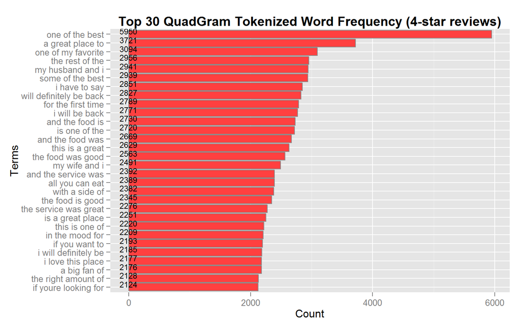

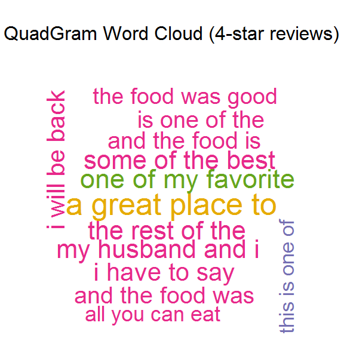